# Tarea_Diplomado

JoséAravena

2022-05-07

*INTRODUCCIÓN*

Los Informes Ambientales (INFAS) son el principal instrumento para la conservación y evaluación de las capacidades de los cuerpos de agua (D.S. N°320/2001, Artículo 3).

Las variables ambientales que se deben analizar para determinar la condición ambiental de un centro de cultivo dependerán de la categoría de clasificación de dicho centro.

Las variables consideradas para este análisis:

-Oxígeno disuelto en la columna de agua (límite de aceptabilidad 2.5 mg/L, 3 estaciones bajo este valor y tendrá condición ambiental será anaeróbica).

-Temperatura en la columna de agua.

-Salinidad en la columna de agua.

-Saturación de oxígeno.

-Condición ambiental.

Del análisis de los Informes Ambientales se entrega una condición ambiental, si es aeróbica, el centro esta apto para un nuevo ciclo productivo, si por el conrtario es anaeróbica, el centro no está apto para un nuevo ciclo productivo hasta que recupere la condición aeróbica.

*DESARROLLO*

**3) Describe la variación de las variables de estudio usando histogramas**

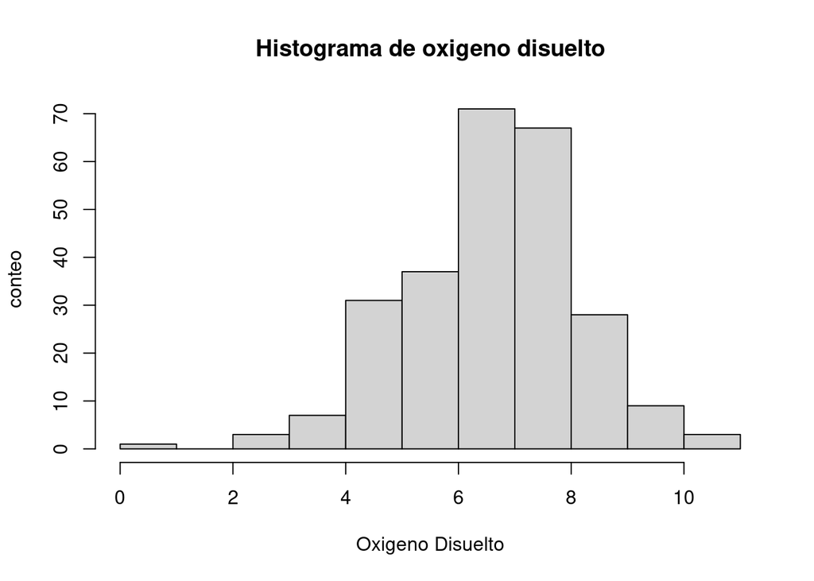

```r
INFAS<-read_excel("INFAS_2021.xls")
hist(x=INFAS$oxigenodisuelto,
     main = "Histograma de oxigeno disuelto",
     xlab = 'Oxigeno Disuelto',
     ylab = 'conteo')
```

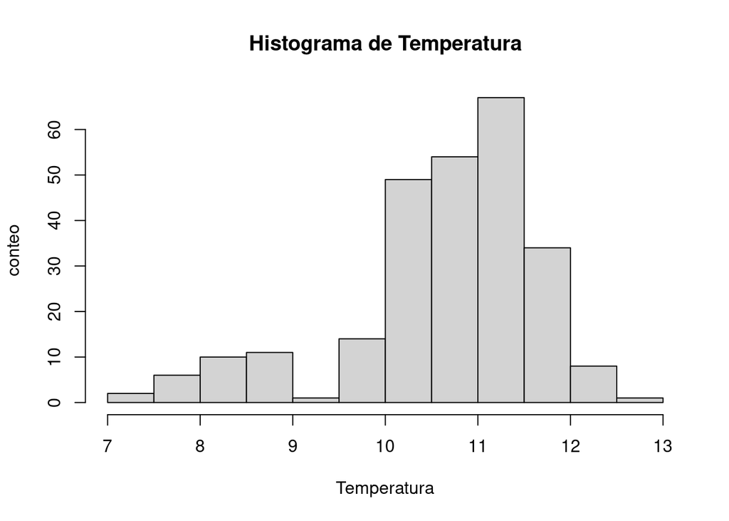

```r
hist(x = INFAS$temperatura, main = "Histograma de Temperatura",
     xlab = 'Temperatura',
     ylab = 'conteo')
```

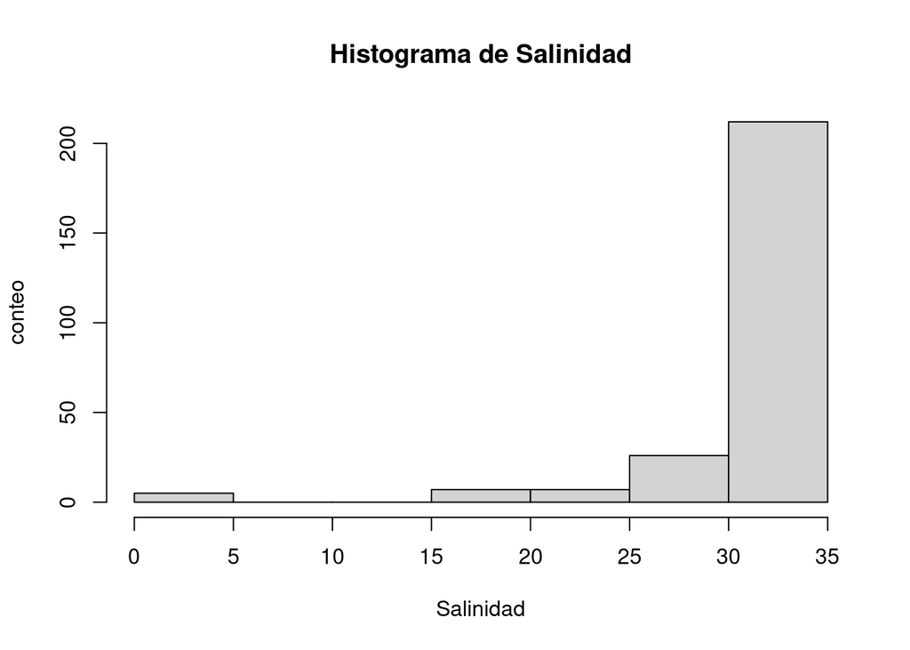

```r
hist(x = INFAS$salinidad, main = "Histograma de Salinidad",
     xlab = 'Salinidad',
     ylab = 'conteo')
```

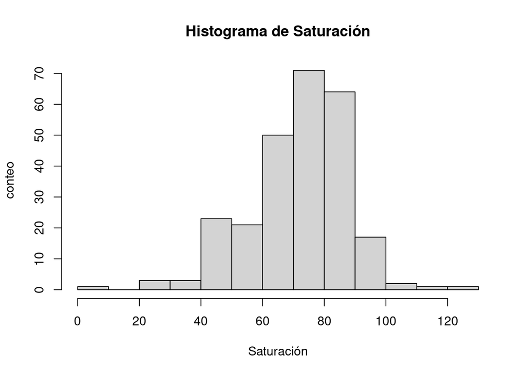

```r
hist(x = INFAS$saturacion, main = "Histograma de Saturación",
     xlab = 'Saturación',
     ylab = 'conteo')
```

**4) Identifica si los datos están balanceados o no entre tratamientos usando tablas de frecuencia**

Primero se elimina la columna profundidad ya que no será utilizada

```r
INFAS <- INFAS[,-2]

table(INFAS$Condición)
```

```
##
##   Aeróbica Anaeróbica
##        223         34
```

```r
prop.table(table(INFAS$Condición))
```

```
##
##   Aeróbica Anaeróbica
##  0.8677043  0.1322957
```

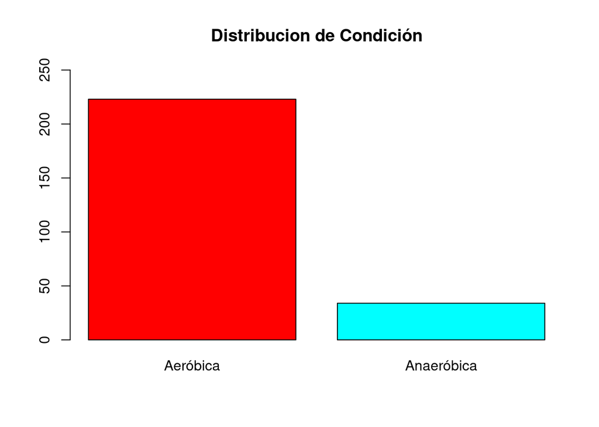

```r
barplot((table(INFAS$Condición)),
        col = rainbow(2),
        ylim = c(0, 250),
        main = "Distribucion de Condición")
```

```r
table(INFAS$Región)
```

```
##
##      Aysén  Los Lagos Magallanes
##        137         90         30
```

```r
prop.table(table(INFAS$Región))
```

```
##
##      Aysén  Los Lagos Magallanes
##  0.5330739  0.3501946  0.1167315
```

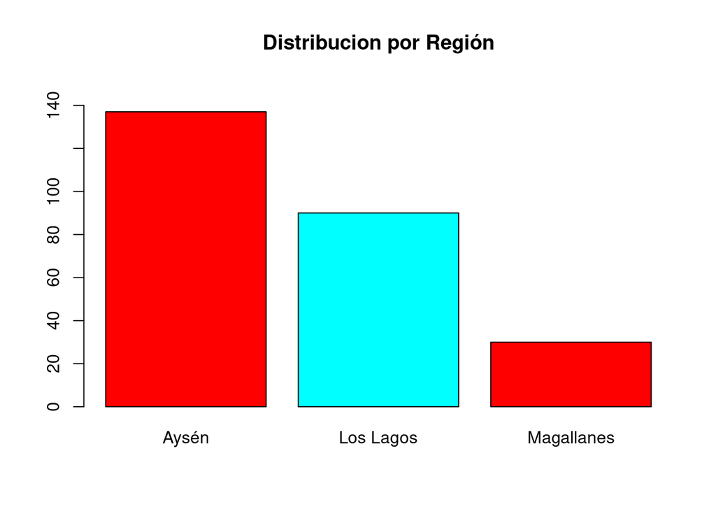

```r
barplot((table(INFAS$Región)),
        col = rainbow(2),
        ylim = c(0, 150),
        main = "Distribucion por Región")
```

**5) Establece relación entre variables cuantitativas y factores usando gráficas de correlación, boxplot, interacción o de tamaño de los efectos**

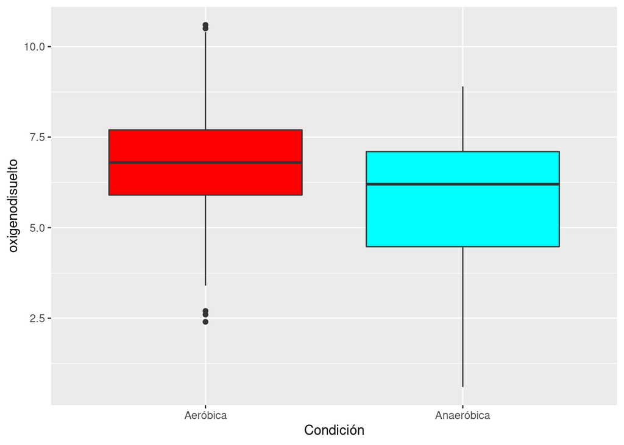

```r
ggplot(data = INFAS, aes(x = Condición, y = oxigenodisuelto)) +
geom_boxplot(fill = rainbow(2))
```

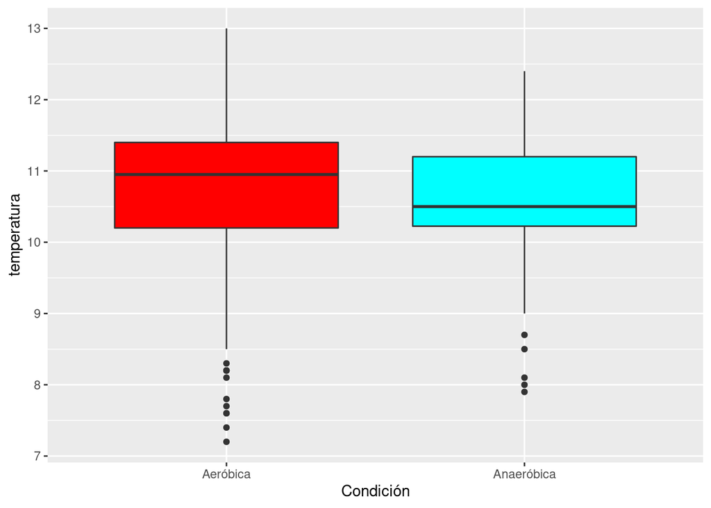

```r
ggplot(data = INFAS, aes(x = Condición, y = temperatura)) +
geom_boxplot(fill = rainbow(2))
```

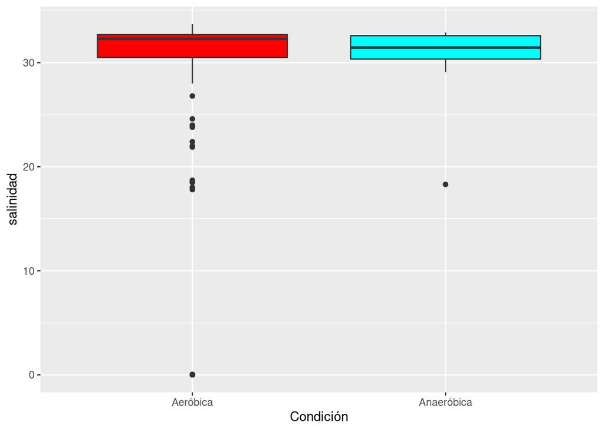

```r
ggplot(data = INFAS, aes(x = Condición, y = salinidad)) +
geom_boxplot(fill = rainbow(2))
```

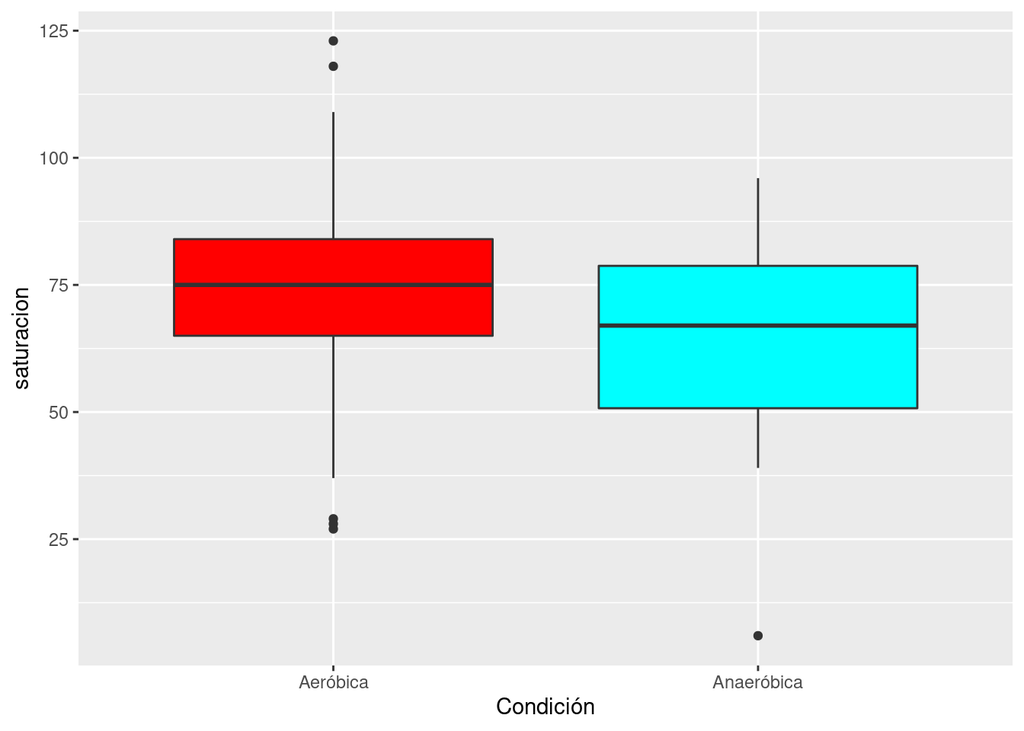

```r
ggplot(data = INFAS, aes(x = Condición, y = saturacion)) +
geom_boxplot(fill = rainbow(2))
```

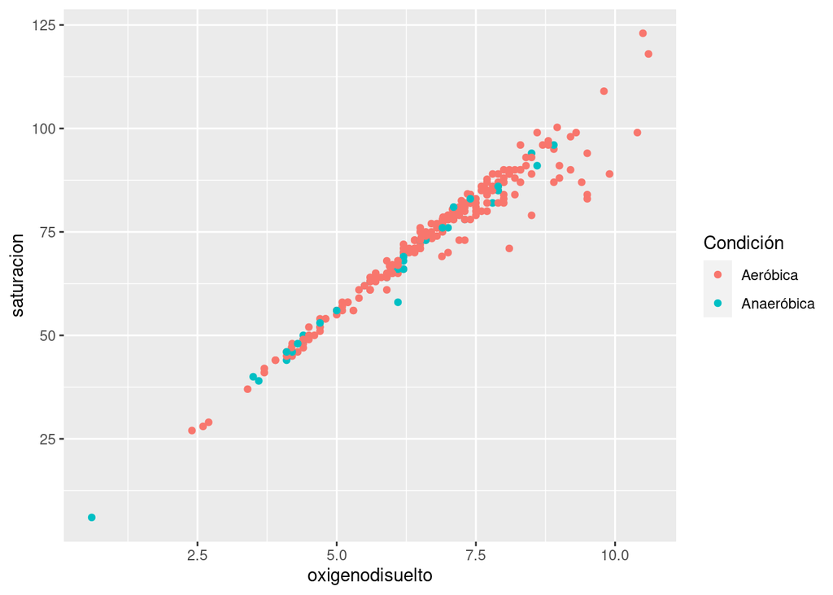

```r
ggplot(INFAS, aes(x = oxigenodisuelto, y = saturacion, color = Condición)) +
  geom_point()
```

Para las variables de Oxígeno disuelto y Saturación, se puede apreciar que los centros con resultado anaeróbico deben tener menores valores de oxígeno y Saturación en la columna de agua. Esto puede no estar representado de la mejor manera ya que por cada centro se toman 8 estaciones y por cada estación se miden datos continuos en la columna de agua. Para este análisis solo se tomaron los datos de la estación 1 de cada centro y a una profundidad de 50 metros. En el diagrama de dispersión, se aprecia que Oxígeno disuelto y Saturación están directamente relacionados.

**6) Identifica si existen errores, datos faltantes o valores atípicos**

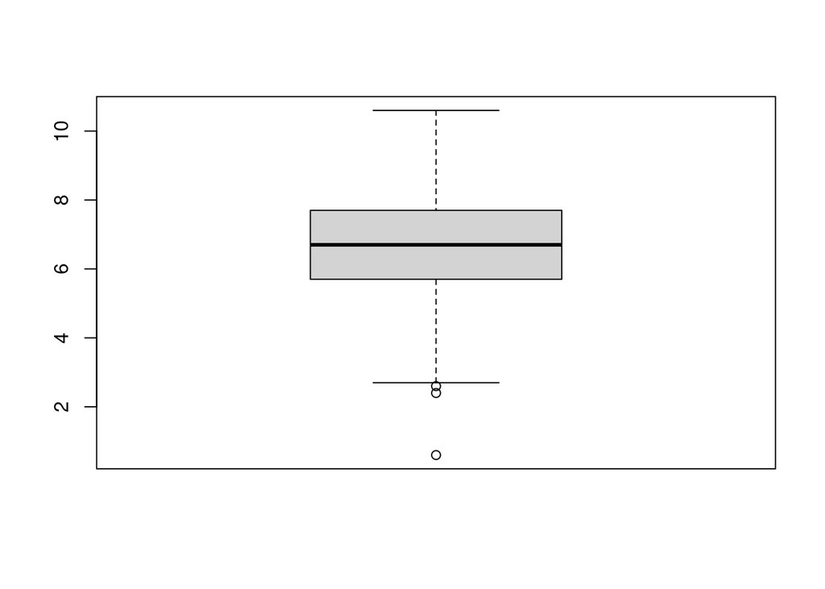

```r
boxplot(INFAS$oxigenodisuelto)
```

```r
boxplot.stats(INFAS$oxigenodisuelto)$out
```

```
## [1] 2.4 0.6 2.6
```

```r
boxplot.stats(INFAS$temperatura)$out
```

```
##  [1] 8.2 8.0 7.8 8.3 8.1 7.9 8.2 8.2 8.1 7.6 7.7 7.6 7.4 7.2
```

```r
boxplot.stats(INFAS$salinidad)$out
```

```
##  [1] 18.00 24.60 21.89 17.80  0.00  0.04 22.00 18.00 23.90 18.30 24.00 23.80
## [13] 18.50 18.50 22.40  0.00 18.70  0.00  0.00 26.80
```

```r
boxplot.stats(INFAS$saturacion)$out
```

```
## [1]  27 118   6  28  29 123
```

-Además, al analizar cada una de las variables, se presentan algunos datos atípicos por ejemplo para oxígeno disuelto valores entre [0.6 y 2.6].

**7) Resume los datos usando tablas y estadística descriptiva**

```r
summary(INFAS)
```

```
##      Centro       oxigenodisuelto   temperatura      salinidad
##  Min.   :100103   Min.   : 0.600   Min.   : 7.20   Min.   : 0.00
##  1st Qu.:102925   1st Qu.: 5.700   1st Qu.:10.20   1st Qu.:30.50
##  Median :110351   Median : 6.700   Median :10.90   Median :32.30
##  Mean   :108724   Mean   : 6.629   Mean   :10.69   Mean   :30.54
##  3rd Qu.:110758   3rd Qu.: 7.700   3rd Qu.:11.40   3rd Qu.:32.70
##  Max.   :120217   Max.   :10.600   Max.   :13.00   Max.   :33.71
##    saturacion     Condición            Región
##  Min.   :  6.0   Length:257         Length:257
##  1st Qu.: 64.0   Class :character   Class :character
##  Median : 74.0   Mode  :character   Mode  :character
##  Mean   : 72.4
##  3rd Qu.: 83.0
##  Max.   :123.0
```

```r
str(INFAS)
```

```
## tibble [257 × 7] (S3: tbl_df/tbl/data.frame)
##  $ Centro         : num [1:257] 110181 110595 110579 101690 120175 ...
##  $ oxigenodisuelto: num [1:257] 4.2 5.9 2.4 7.4 9.2 7.5 5.7 5.6 5.6 4.8 ...
##  $ temperatura    : num [1:257] 10.1 10.3 10.7 11 8.2 10.6 11 11 11 11.3 ...
##  $ salinidad      : num [1:257] 30.3 30.3 31.4 30.6 18 30.3 32.4 32.4 32.4 32.6 ...
##  $ saturacion     : num [1:257] 45 64 27 82 90 81 64 63 63 54 ...
##  $ Condición      : chr [1:257] "Aeróbica" "Anaeróbica" "Aeróbica" "Aeróbica" ...
##  $ Región         : chr [1:257] "Aysén" "Aysén" "Aysén" "Los Lagos" ...
```

```r
sd(INFAS$oxigenodisuelto)
```

```
## [1] 1.55016
```

```r
sd(INFAS$salinidad)
```

```
## [1] 5.170798
```

```r
sd(INFAS$temperatura)
```

```
## [1] 1.064121
```

```r
sd(INFAS$saturacion)
```

```
## [1] 16.0469
```

Se puede apreciar que la variable condición ambiental y Región fueron codificada como caracter o texto (chr) en vez de factor

```r
INFAS$Condición<-as.factor(INFAS$Condición)
summary(INFAS$Condición)
```

```
##   Aeróbica Anaeróbica
##        223         34
```

```r
INFAS$Región<-as.factor(INFAS$Región)
str(INFAS)
```

```
## tibble [257 × 7] (S3: tbl_df/tbl/data.frame)
##  $ Centro         : num [1:257] 110181 110595 110579 101690 120175 ...
##  $ oxigenodisuelto: num [1:257] 4.2 5.9 2.4 7.4 9.2 7.5 5.7 5.6 5.6 4.8 ...
##  $ temperatura    : num [1:257] 10.1 10.3 10.7 11 8.2 10.6 11 11 11 11.3 ...
##  $ salinidad      : num [1:257] 30.3 30.3 31.4 30.6 18 30.3 32.4 32.4 32.4 32.6 ...
##  $ saturacion     : num [1:257] 45 64 27 82 90 81 64 63 63 54 ...
##  $ Condición      : Factor w/ 2 levels "Aeróbica","Anaeróbica": 1 2 1 1 1 1 1 1 1 1 ...
##  $ Región         : Factor w/ 3 levels "Aysén","Los Lagos",..: 1 1 1 2 3 2 2 2 2 2 ...
```

**8) Utiliza paquetes para importar datos a R como readxl o similar, y paquetes tidyr dplyr, ggplot2 para el análisis exploratorio de datos o similar según la naturaleza de los datos**

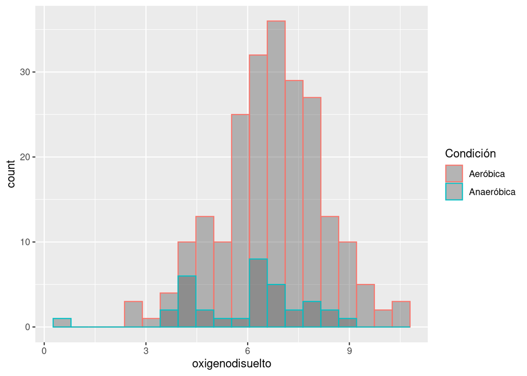

```r
ggplot(INFAS, aes(x = oxigenodisuelto)) +
  geom_histogram(aes(color = Condición), position = "identity", bins = 20, alpha = 0.4)
```

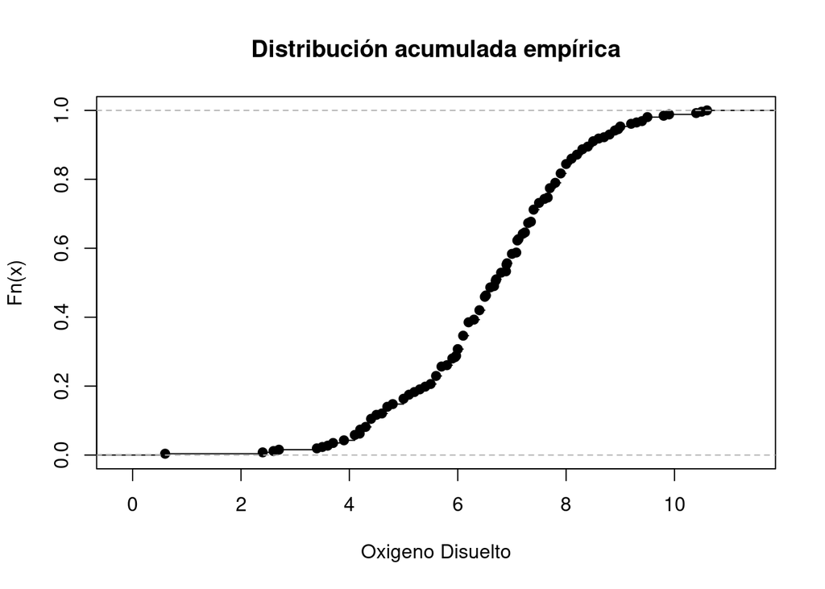

```r
plot(ecdf(INFAS$oxigenodisuelto), xlab = 'Oxigeno Disuelto',main = "Distribución acumulada empírica")
```

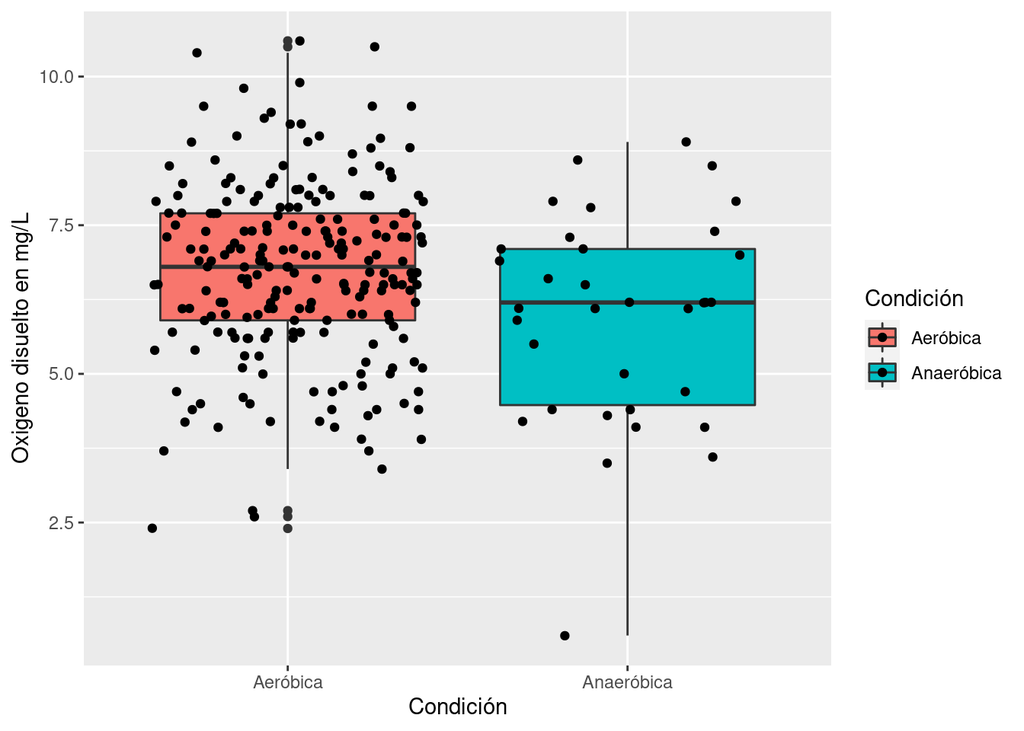

```r
ggplot(INFAS, aes(y=oxigenodisuelto, x=Condición, fill = Condición))+
  geom_boxplot()+  geom_jitter()+
labs(y="Oxigeno disuelto en mg/L")
```

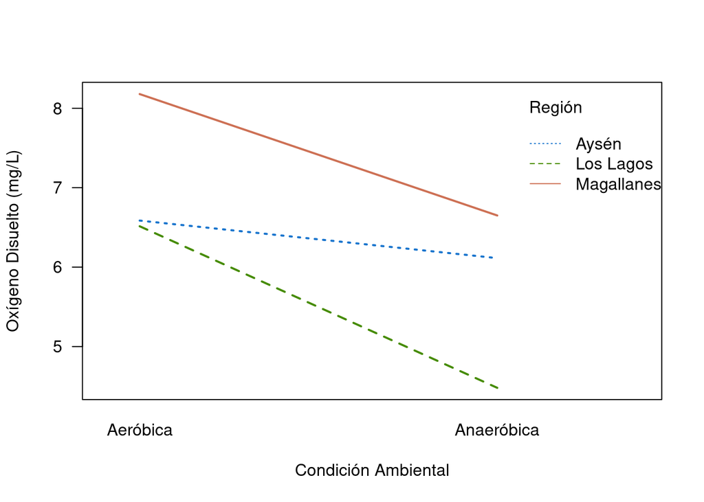

```r
interaction.plot(x.factor=INFAS$Condición, trace.factor=INFAS$Región,
                 response=INFAS$oxigenodisuelto, trace.label='Región',
                 xlab='Condición Ambiental',
                 ylab='Oxígeno Disuelto (mg/L)',
                 col=c('dodgerblue3', 'chartreuse4', 'salmon3'),
                 fun=mean, lwd=2, las=1, fixed=T)
```

*CONCLUSIONES*

Para las variables Condición y Región, se pudo ver que no están balanceados. Pero esto tiene que ver directamente para el caso de Región como se distribuyen los centros de cultivo.

Para el caso de oxígeno disuelto y saturación se pudo observar de manera más clara la relación con la condición ambiental, donde para los casos de anaerobiosis el oxígeno y porcentaje de saturación es menor que en los casos con condición aeróbica. Además, mediante diagrama de dispersión, se aprecia que Oxígeno disuelto y Saturación están directamente relacionados.

Mediante la función interaction.plot se pudo analizar como influye la región en la cantidad de oxígeno disuelto, mostrando claramente que en la región de los Lagos esta es más baja que en las otras regiones.

Finalmente es necesario para tener análisis más robustos considerar una base más completa e incluir todos los valores por estaciones que no fueron considerados para esta. De todas maneras esta muestra nos permite hacernos una idea del comportamiento de las variables y sus relaciones.